# Music Genre Classification Task

Uzor Chike

2024-04-03

# Introduction

In this assignment, I aim to perform music classification using machine learning techniques in R. the dataset, sourced from Kaggle, consists of audio features extracted from various music tracks along with their respective genres. We will explore the dataset, preprocess the data, engineer features if necessary, build machine learning models for classification, and evaluate their performance.

## Loading Libraries

```r
library(dplyr)
library(tidyverse)
```

```r
library(ggplot2)
library(caret)
```

## Importing Dataset

```r
data <- read.csv('music_genre.csv')
Music <- data.frame(data)
head(Music)
```

```
##   instance_id          artist_name           track_name popularity acousticness
## 1       32894             Röyksopp Röyksopp's Night Out         27      0.00468
## 2       46652 Thievery Corporation     The Shining Path         31      0.01270
## 3       30097       Dillon Francis            Hurricane         28      0.00306
## 4       62177             Dubloadz                Nitro         34      0.02540
## 5       24907          What So Not     Divide & Conquer         32      0.00465
## 6       89064           Axel Boman                Hello         47      0.00523
##   danceability duration_ms energy instrumentalness key liveness loudness  mode
## 1        0.652          -1  0.941          0.79200  A#    0.115   -5.201 Minor
## 2        0.622      218293  0.890          0.95000   D    0.124   -7.043 Minor
## 3        0.620      215613  0.755          0.01180  G#    0.534   -4.617 Major
## 4        0.774      166875  0.700          0.00253  C#    0.157   -4.498 Major
## 5        0.638      222369  0.587          0.90900  F#    0.157   -6.266 Major
## 6        0.755      519468  0.731          0.85400   D    0.216  -10.517 Minor
##   speechiness              tempo obtained_date valence music_genre
## 1      0.0748            100.889         4-Apr   0.759  Electronic
## 2      0.0300 115.00200000000001         4-Apr   0.531  Electronic
## 3      0.0345            127.994         4-Apr   0.333  Electronic
## 4      0.2390            128.014         4-Apr   0.270  Electronic
## 5      0.0413            145.036         4-Apr   0.323  Electronic
## 6      0.0412                  ?         4-Apr   0.614  Electronic
```

## Feature Selection

Removal of features that have no impact on the learning process

```r
Music <- subset(Music, select = -c(instance_id, obtained_date, popularity, track_name, artist_name))
head(Music)
```

```
##   acousticness danceability duration_ms energy instrumentalness key liveness
## 1      0.00468        0.652          -1  0.941          0.79200  A#    0.115
## 2      0.01270        0.622      218293  0.890          0.95000   D    0.124
## 3      0.00306        0.620      215613  0.755          0.01180  G#    0.534
## 4      0.02540        0.774      166875  0.700          0.00253  C#    0.157
## 5      0.00465        0.638      222369  0.587          0.90900  F#    0.157
## 6      0.00523        0.755      519468  0.731          0.85400   D    0.216
##   loudness  mode speechiness              tempo valence music_genre
## 1   -5.201 Minor      0.0748            100.889   0.759  Electronic
## 2   -7.043 Minor      0.0300 115.00200000000001   0.531  Electronic
## 3   -4.617 Major      0.0345            127.994   0.333  Electronic
## 4   -4.498 Major      0.2390            128.014   0.270  Electronic
## 5   -6.266 Major      0.0413            145.036   0.323  Electronic
## 6  -10.517 Minor      0.0412                  ?   0.614  Electronic
```

## Pre-processing

Removal of inconsistencies, duplicates, missing values etc

```r
sapply(Music, function(x) sum(is.na(x)))
```

```
##     acousticness     danceability      duration_ms           energy
##                5                5                5                5
## instrumentalness              key         liveness         loudness
##                5                0                5                5
##             mode      speechiness            tempo          valence
##                0                5                0                5
##      music_genre
##                0
```

```r
Music <- na.omit(Music)
Music <- Music[Music$tempo != "?", ]
Music <- Music[Music$duration_ms != "-1", ]
Music$tempo <- as.numeric(Music$tempo)
```

## Exloratory Data Analysis

```r
glimpse(Music)
```

```
## Rows: 40,560
## Columns: 13
## $ acousticness     <dbl> 1.27e-02, 3.06e-03, 2.54e-02, 4.65e-03, 2.89e-02, 2.9…
## $ danceability     <dbl> 0.622, 0.620, 0.774, 0.638, 0.572, 0.809, 0.509, 0.57…
## $ duration_ms      <dbl> 218293, 215613, 166875, 222369, 214408, 416132, 29280…
## $ energy           <dbl> 0.890, 0.755, 0.700, 0.587, 0.803, 0.706, 0.921, 0.73…
## $ instrumentalness <dbl> 9.50e-01, 1.18e-02, 2.53e-03, 9.09e-01, 7.74e-06, 9.0…
## $ key              <chr> "D", "G#", "C#", "F#", "B", "G", "F", "A", "F#", "B",…
## $ liveness         <dbl> 0.1240, 0.5340, 0.1570, 0.1570, 0.1060, 0.0635, 0.178…
## $ loudness         <dbl> -7.043, -4.617, -4.498, -6.266, -4.294, -9.339, -3.17…
## $ mode             <chr> "Minor", "Major", "Major", "Major", "Major", "Minor",…
## $ speechiness      <dbl> 0.0300, 0.0345, 0.2390, 0.0413, 0.3510, 0.0484, 0.268…
## $ tempo            <dbl> 115.002, 127.994, 128.014, 145.036, 149.995, 120.008,…
## $ valence          <dbl> 0.5310, 0.3330, 0.2700, 0.3230, 0.2300, 0.7610, 0.273…
## $ music_genre      <chr> "Electronic", "Electronic", "Electronic", "Electronic…
```

```r
summary(Music)
```

```
##   acousticness    danceability     duration_ms          energy
##  Min.   :0.000   Min.   :0.0596   Min.   :  15509   Min.   :0.000792
##  1st Qu.:0.020   1st Qu.:0.4420   1st Qu.: 190480   1st Qu.:0.433000
##  Median :0.144   Median :0.5690   Median : 227533   Median :0.644000
##  Mean   :0.306   Mean   :0.5584   Mean   : 245490   Mean   :0.600330
##  3rd Qu.:0.550   3rd Qu.:0.6870   3rd Qu.: 275760   3rd Qu.:0.817000
##  Max.   :0.996   Max.   :0.9860   Max.   :4497994   Max.   :0.999000
##  instrumentalness       key               liveness          loudness
##  Min.   :0.000000   Length:40560       Min.   :0.00967   Min.   :-47.046
##  1st Qu.:0.000000   Class :character   1st Qu.:0.09700   1st Qu.:-10.843
##  Median :0.000157   Mode  :character   Median :0.12600   Median : -7.277
##  Mean   :0.181603                      Mean   :0.19382   Mean   : -9.126
##  3rd Qu.:0.152000                      3rd Qu.:0.24400   3rd Qu.: -5.174
##  Max.   :0.996000                      Max.   :1.00000   Max.   :  3.744
##      mode            speechiness          tempo           valence
##  Length:40560       Min.   :0.02230   Min.   : 34.35   Min.   :0.0000
##  Class :character   1st Qu.:0.03610   1st Qu.: 94.89   1st Qu.:0.2590
##  Mode  :character   Median :0.04890   Median :119.76   Median :0.4490
##                     Mean   :0.09374   Mean   :119.87   Mean   :0.4569
##                     3rd Qu.:0.09880   3rd Qu.:140.34   3rd Qu.:0.6480
##                     Max.   :0.94200   Max.   :220.28   Max.   :0.9920
##  music_genre
##  Length:40560
##  Class :character
##  Mode  :character
##
##
##
```

```r
names(Music)
```

```
##  [1] "acousticness"     "danceability"     "duration_ms"      "energy"
##  [5] "instrumentalness" "key"              "liveness"         "loudness"
##  [9] "mode"             "speechiness"      "tempo"            "valence"
## [13] "music_genre"
```

```r
sapply(Music, class)
```

```
##     acousticness     danceability      duration_ms           energy
##        "numeric"        "numeric"        "numeric"        "numeric"
## instrumentalness              key         liveness         loudness
##        "numeric"      "character"        "numeric"        "numeric"
##             mode      speechiness            tempo          valence
##      "character"        "numeric"        "numeric"        "numeric"
##      music_genre
##      "character"
```

## Plots

### Target Variable Distribution

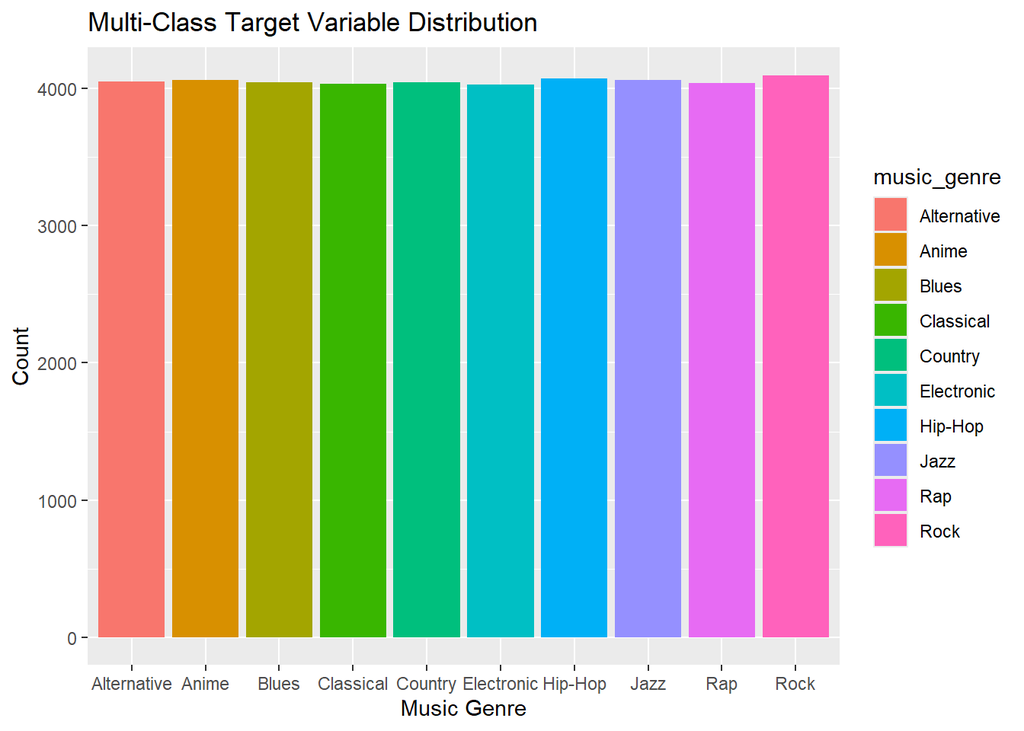

```r
ggplot(Music, aes(x = music_genre, fill = music_genre)) +
  geom_bar() +
  labs(x = "Music Genre", y = "Count", title = "Multi-Class Target Variable Distribution")
```

Based on domain knowledge, it is understood that rap music is often categorized under the broader genre of hip hop. To ensure clarity and minimize potential misclassifications within my model, as well as to prevent overpopulation of one class in the target variable, I have opted to exclude the rap genre from the classification categories.

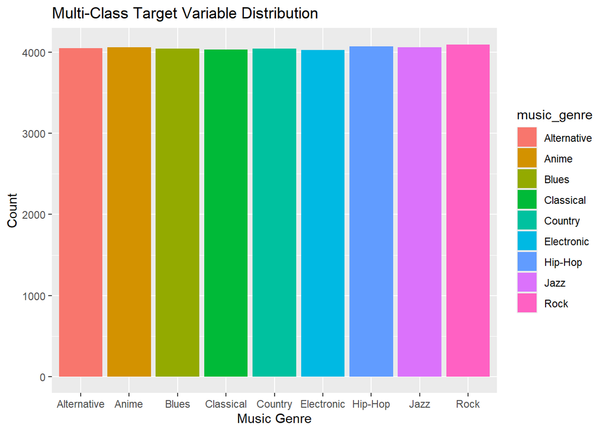

```r
Music <- Music[Music$music_genre != "Rap", ]

ggplot(Music, aes(x = music_genre, fill = music_genre)) +
  geom_bar() +
  labs(x = "Music Genre", y = "Count", title = "Multi-Class Target Variable Distribution")
```

### Plotting the Correlation Matrix Across the Numeric Features

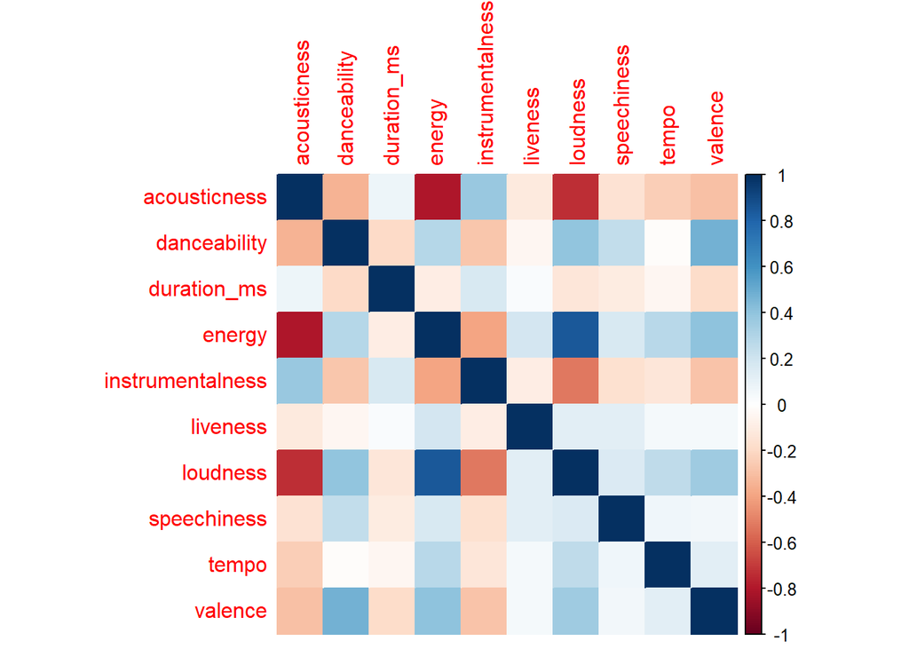

```r
library(corrplot)
Music_numeric <- subset (Music, select = -c(key, mode, music_genre))
correlation_matrix <- cor(Music_numeric)
correlation_df <- as.data.frame(correlation_matrix)
corrplot(correlation_matrix, method = "color")
```

### Visualizing Distribution Of Categorical Features

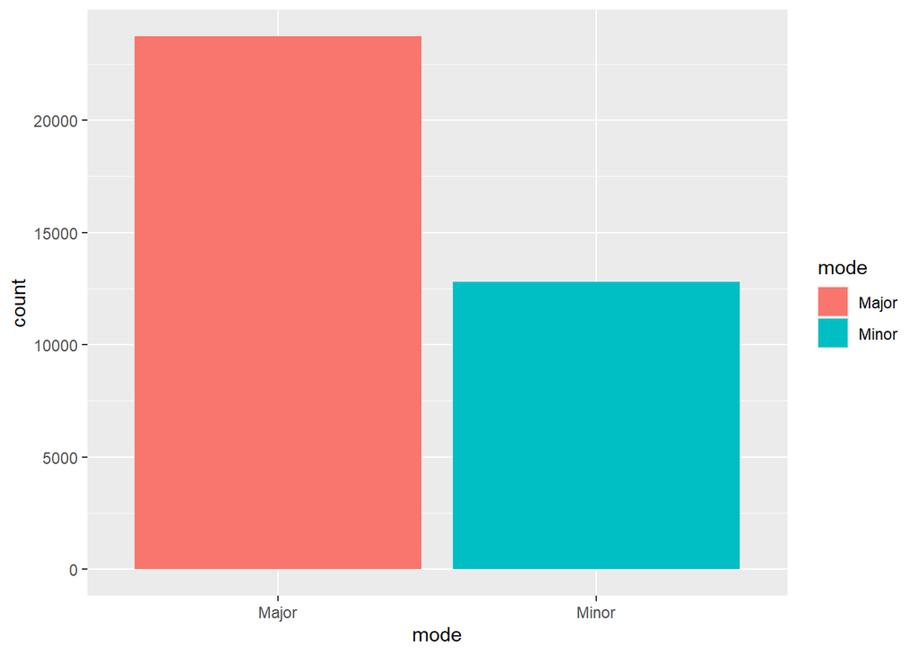

```r
ggplot(Music, aes(x = mode, fill = mode)) +
  geom_bar()
```

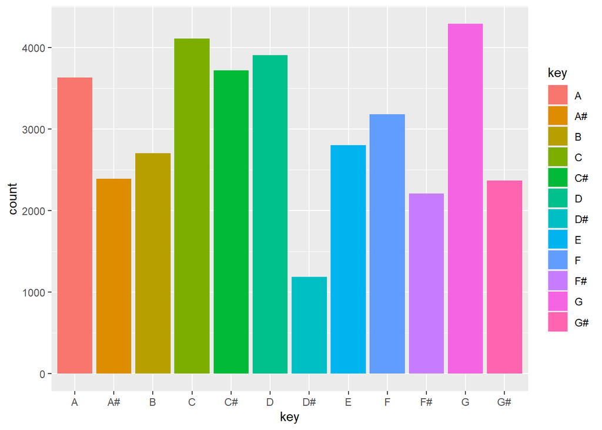

```r
ggplot(Music, aes(x = key, fill = key)) +
  geom_bar()
```

### Visualizing Tempo across Various Music Genres

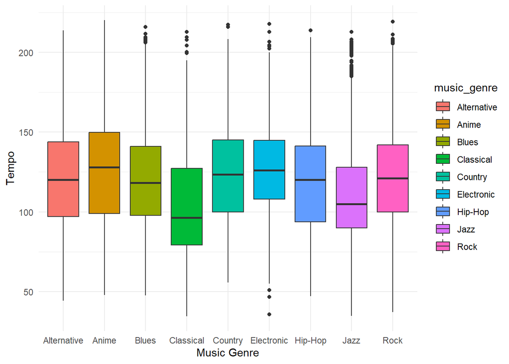

```r
ggplot(Music, aes(x = music_genre, y = tempo, fill = music_genre)) +
  geom_boxplot() +
  labs(x = "Music Genre", y = "Tempo") +
  theme_minimal()
```

Classical music generally have lower tempo as opposed to Electronic/Dance and Anime

### How danceable are these music genres?

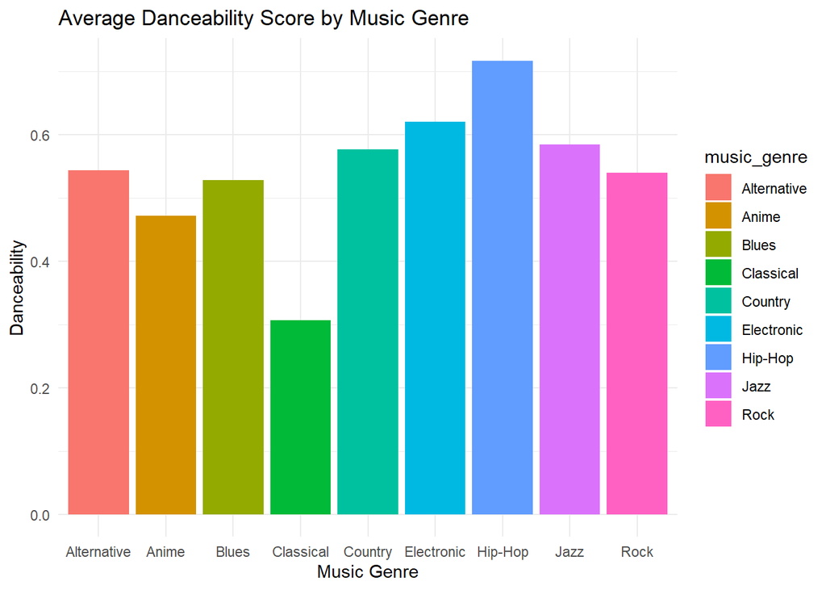

```r
ggplot(Music, aes(x = music_genre, y = danceability, fill = music_genre)) +
  geom_bar(stat = "summary", fun = "mean") +
  labs(x = "Music Genre", y = "Danceability", title = "Average Danceability Score by Music Genre") +
  theme_minimal()
```

Hip hop and Elctronic Music are generally more danceable than Classical or Blues.

### From the correlation matrix plotted above, we can see that energy and loudness have a positive correlation. Let’s visualize how these features affect the Music genres.

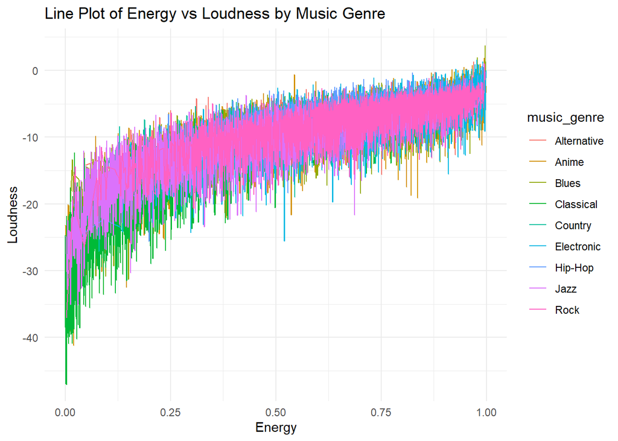

```r
ggplot(Music, aes(x = energy, y = loudness, color = music_genre)) +
  geom_line() +
  labs(x = "Energy", y = "Loudness", title = "Line Plot of Energy vs Loudness by Music Genre") +
  theme_minimal()
```

A clear trend emerges indicating that higher levels of energy correspond to higher levels of loudness across all classes of music genres. This displays a positive correlation between energy and loudness in the dataset.

### Normalizing numeric columns using min-max scaling

```r
numeric_cols <- sapply(Music, is.numeric)
Music_normalized <- Music
Music_normalized[, numeric_cols] <- lapply(Music_normalized[, numeric_cols], function(x) (x-min(x)) / (max(x) - min(x)))
head(Music_normalized)
```

```
##   acousticness danceability duration_ms    energy instrumentalness key
## 2  0.012751004    0.6070812  0.04523919 0.8908043     9.538153e-01   D
## 3  0.003072289    0.6049223  0.04464131 0.7555620     1.184739e-02  G#
## 4  0.025502008    0.7711572  0.03376832 0.7004632     2.540161e-03  C#
## 5  0.004668675    0.6243523  0.04614851 0.5872604     9.126506e-01  F#
## 7  0.029016064    0.5531088  0.04437249 0.8036481     7.771084e-06   B
## 8  0.029819277    0.8089378  0.08937520 0.7064740     9.066265e-01   G
##     liveness  loudness  mode speechiness     tempo   valence music_genre
## 2 0.11544637 0.7876157 Minor 0.008372295 0.4337946 0.5352823  Electronic
## 3 0.52944978 0.8353810 Major 0.013265195 0.5036708 0.3356855  Electronic
## 4 0.14876859 0.8377240 Major 0.235620311 0.5037783 0.2721774  Electronic
## 5 0.14876859 0.8029140 Major 0.020658911 0.5953294 0.3256048  Electronic
## 7 0.09727061 0.8417405 Major 0.357399152 0.6220009 0.2318548  Electronic
## 8 0.05435562 0.7424099 Minor 0.028378819 0.4607189 0.7671371  Electronic
```

```r
Music <- Music_normalized
```

### Grouped Bar Chart

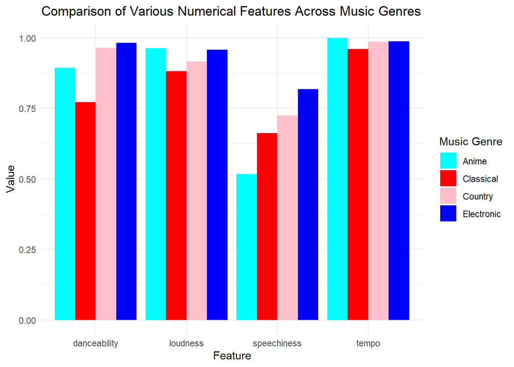

```r
subset_data <- Music[Music$music_genre %in% c("Electronic", "Classical", "Country", "Anime"),]

library(tidyr)
subset_data_long <- gather(subset_data, key = "feature", value = "value", tempo, loudness, speechiness, danceability)


#Create a grouped bar chart
ggplot(subset_data_long, aes(x = feature, y = value, fill = music_genre)) +
  geom_bar(stat = "identity", position = "dodge") +
  theme_minimal() +
  labs(title = "Comparison of Various Numerical Features Across Music Genres",
       x = "Feature",
       y = "Value",
       fill = "Music Genre") +
  scale_fill_manual(values = c("Electronic" = "blue", "Classical" = "red", "Country" = "pink", "Anime" = "cyan"))
```

# Building a Classification Model to Predict Music Genres

### Data Reduction

Given the limitations of my system specifications and the size of the dataset, I decided to perform numerosity reduction based on the distribution of the target variable.

```r
desired_rows <- 34000
set.seed(123)
sampled_indices <- sample(nrow(Music), desired_rows, replace = TRUE)
sampled_data <- Music[sampled_indices, ]
table(sampled_data$music_genre)
```

```
##
## Alternative       Anime       Blues   Classical     Country  Electronic
##        3778        3763        3676        3843        3795        3671
##     Hip-Hop        Jazz        Rock
##        3746        3804        3924
```

```r
Music<- sampled_data
```

### Label encoding categorical features

```r
Music$key <- factor(Music$key)
Music$mode <- factor(Music$mode)
Music$music_genre <- factor(Music$music_genre)
sapply(Music, class)
```

```
##     acousticness     danceability      duration_ms           energy
##        "numeric"        "numeric"        "numeric"        "numeric"
## instrumentalness              key         liveness         loudness
##        "numeric"         "factor"        "numeric"        "numeric"
##             mode      speechiness            tempo          valence
##         "factor"        "numeric"        "numeric"        "numeric"
##      music_genre
##         "factor"
```

All categorical features are now factors

### Split Dataset into training and testing

```r
set.seed((100))
TrainingIndex <- createDataPartition(Music$music_genre, p=0.8, list = FALSE)
TrainingSet <- Music[TrainingIndex, ]
TestingSet <- Music[-TrainingIndex, ]

X_Train <- TrainingSet[, -13]
Y_Train <- TrainingSet[, 13]

X_Test <- TestingSet[, -13]
Y_Test <- TestingSet[, 13]
head(X_Train)
```

```
##       acousticness danceability duration_ms     energy instrumentalness key
## 3713   0.125502008    0.8013817 0.092134385 0.49709880        0.8504016  A#
## 41890  0.997991968    0.2012090 0.007772028 0.07484212        0.9267068   C
## 41621  0.981927711    0.3469344 0.091579559 0.22461050        0.8775100   G
## 3428   0.001134538    0.5444732 0.035722819 0.94189588        0.4558233   C
## 11930  0.476907631    0.7851900 0.058315421 0.69144707        0.0000000  A#
## 43594  0.888554217    0.1806995 0.201343228 0.10439508        0.7008032   D
##         liveness  loudness  mode speechiness     tempo    valence
## 3713  0.34163360 0.6215594 Minor  0.04610199 0.4607780 0.07056452
## 41890 0.09929014 0.4103957 Major  0.01402631 0.3299432 0.41028226
## 41621 0.09929014 0.5546761 Minor  0.01674459 0.6071941 0.43346774
## 3428  0.15482718 0.8591455 Major  0.02990105 0.4068058 0.30544355
## 11930 0.08707199 0.7988580 Minor  0.03512015 0.3494183 0.97076613
## 43594 0.08747589 0.4734200 Major  0.02305099 0.2744704 0.05987903
```

## Using Random Forest Algorithm

```r
library(randomForest)
Model <- randomForest(x = X_Train,
                      y = Y_Train,
                      mtry = 4,
                      ntree = 501,
                      max_depth = 15,
                      min_samples_leaf = 200,
                      importance = TRUE)
print(Model)
```

```
##
## Call:
##  randomForest(x = X_Train, y = Y_Train, ntree = 501, mtry = 4,      importance = TRUE, max_depth = 15, min_samples_leaf = 200)
##                Type of random forest: classification
##                      Number of trees: 501
## No. of variables tried at each split: 4
##
##         OOB estimate of  error rate: 24.26%
## Confusion matrix:
##             Alternative Anime Blues Classical Country Electronic Hip-Hop Jazz
## Alternative        1862   147   107         4     159        119     249   90
## Anime               137  2300    54       154      88         89      26   85
## Blues               101    90  2077        24     157         67      38  218
## Classical            41    46    27      2860       5         29       3   56
## Country              79    62   144         2    2397          8      97   49
## Electronic          102    77    51         8      25       2346      89  193
## Hip-Hop              93    20    31         0      56         57    2682   35
## Jazz                 43    40   192       112      40        188      95 2306
## Rock                330   128   273         8     385         88      57   98
##             Rock class.error
## Alternative  286   0.3840556
## Anime         78   0.2361342
## Blues        169   0.2937776
## Classical      8   0.0699187
## Country      198   0.2104743
## Electronic    46   0.2012257
## Hip-Hop       23   0.1051051
## Jazz          28   0.2424442
## Rock        1773   0.4353503
```

### Making Predictions

```r
predictions <- predict(Model, newdata = X_Test)
```

### Accuracy Test

```r
accuracy <- mean(predictions == Y_Test)
print(paste("Accuracy:", round(accuracy * 100, 2), "%"))
```

```
## [1] "Accuracy: 74.99 %"
```

An accuracy of approximately 75% can be considered good, given that we have a total of 9 classes to predict.

# Conclusion

Overall, the analysis provides insights into the feasibility and effectiveness of using machine learning techniques for music classification tasks, offering valuable implications for music recommendation systems and genre-based playlist generation algorithms.